# Approximation Benchmark

Here we will examine the approximation method for value of information analyses. To achieve this, we will compare estimates from the approximation method against the correct values from the exact methods. A crucial part of the approximation method involves generating a subset of outcomes to *approximate* the full set of outcomes, and so we will investigate several different methods for generating outcomes. We will also examine how the number of approximation outcomes affects the quality of the estimate.

## Setup

Let’s start by setting up our R session. Here we will load some R packages and pre-set the random number generators for reproducibility.

```r
# load packages
library(surveyvoi)
library(dplyr)
library(tidyr)
library(ggplot2)
library(tibble)
library(gridExtra)
library(viridis)
library(RandomFields)

# set RNG seeds for reproducibility
set.seed(505)
RFoptions(seed = 505)

# set default table printing options
options(pillar.sigfig = 6)
```

## Simulate data

```r
# simulate site data
site_data <- simulate_site_data(
  n_sites = 15, n_features = 1, proportion_of_sites_missing_data = 5 / 15)
```

```
## ...
```

```r
# print site data
print(site_data)
```

```
## Simple feature collection with 15 features and 7 fields
## geometry type:  POINT
## dimension:      XY
## bbox:           xmin: 0.02070792 ymin: 0.01366063 xmax: 0.7855831 ymax: 0.9272025
## CRS:            NA
## # A tibble: 15 x 8
##    survey_cost management_cost         e1         e2        e3    f1         p1
##          <dbl>           <dbl>      <dbl>      <dbl>     <dbl> <dbl>      <dbl>
##  1     8.78717         69.5624  0.352685  -0.615935  -0.728549     0 4.36348e-1
##  2     5.36696         64.8589 -0.612633   1.15596    0.718512    NA 1.68621e-1
##  3     6.25925         57.5309 -1.53741   -0.281868   1.29149     NA 9.99848e-1
##  4     8.81519         66.1143  1.14228   -1.24025   -0.839952     1 5.89391e-1
##  5     5.45039         62.7456 -1.01539   -0.409767   0.518910     1 9.96994e-1
##  6     4.37280         60.5701  1.43650    2.52796   -0.253192     0 1.78871e-7
##  7     8.76247         67.2501  0.0259090 -0.402047  -0.519918    NA 5.44848e-1
##  8     8.80315         65.1071  0.838224  -0.894822  -0.878425     0 3.55422e-1
##  9     9.57884         66.6267  0.347615  -0.0776230 -0.635106    NA 8.41553e-2
## 10     6.37048         65.9617  1.08574   -0.560094  -0.813593     0 7.65414e-2
## 11     8.75928         67.5310  0.496681   0.0117405 -0.682279     0 3.61501e-2
## 12     9.58011         64.8944  0.722107  -0.580667  -0.846134    NA 1.62489e-1
## 13     5.49527         58.2507 -1.44014   -0.152584   1.18873      1 9.99533e-1
## 14     7.11370         64.8953 -0.608469  -0.0494300  0.128359     1 8.85234e-1
## 15     5.19364         70.5367 -1.23370    1.56944    2.35114      1 9.49581e-1
## # … with 1 more variable: geometry <POINT>
```

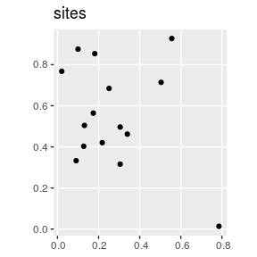

```r
# plot the spatial location of the sites
ggplot(site_data) +
  geom_sf() +
  ggtitle("sites")
```

The `site_data` object is a spatially explicit dataset (i.e. `sf`) that contains information on the site locations and additional information for each site too. Here, each row corresponds to a different site and each column contains different information about the sites. The `f1` column contains the results from previous surveys, where ones indicate that the feature was previously detected at a site, zeros indicate that the feature has not previously been detected at a site, and missing (`NA`) values mean that a site has not yet been surveyed. The `p1` column contains modelled probability of occupancy predictions from environmental niche models. The `e1`, `e2`, and `e3` columns contain environmental variables for each site. The `survey_cost` column contains the cost for surveying each site, and the `management_cost` column contains the cost for managing each site for conservation. Although the `site_data` object contains additional columns, they are not relevant here and so we will not bother with them. To help understand the simulated data, let’s create some visualizations.

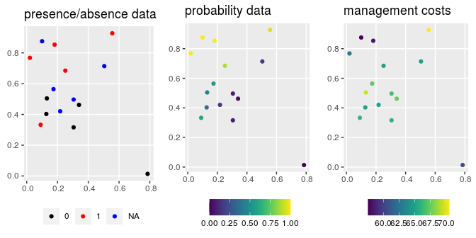

```r
# map of site occupancy data from previous surveys
p1 <-
  site_data %>%
  mutate(f1 = as.character(f1)) %>%
  ggplot() +
  geom_sf(aes(color = f1)) +
  scale_color_manual(name = "", values = c("1" = "red", "0" = "black"),
                     na.value = "blue") +
  labs(title = "presence/absence data") +
  theme(legend.position = "bottom")

# make map of modelled probability of occupancy data
p2 <-
  site_data %>%
  ggplot() +
  geom_sf(aes(color = p1)) +
  scale_color_viridis(name = "", limits = c(0, 1)) +
  labs(title = "probability data") +
  theme(legend.position = "bottom")

# make map of site occupancy data from previous surveys
p3 <-
  site_data %>%
  ggplot() +
  geom_sf(aes(color = management_cost)) +
  scale_color_viridis(name = "") +
  labs(title = "management costs") +
  theme(legend.position = "bottom")

# display plots
grid.arrange(p1, p2, p3, nrow = 1)
```

Next, we will simulate a survey scheme. This survey scheme will contain four of the five sites that have not previously been surveyed.

```r
# generate survey scheme
site_data$survey_scheme <-
  replace(rep(FALSE, nrow(site_data)), sample(which(is.na(site_data$f1)), 4),
          TRUE)

# print survey scheme
print(site_data$survey_scheme)
```

```
##  [1] FALSE  TRUE  TRUE FALSE FALSE FALSE  TRUE FALSE FALSE FALSE FALSE  TRUE
## [13] FALSE FALSE FALSE
```

We will also set a total budget for surveying sites and managing sites for conservation. This budget will be 80% of the total costs of all planning units.

```r
# set total budget
total_budget <- sum(site_data$management_cost) * 0.8

# print total budget
print(total_budget)
```

```
## [1] 777.9488
```

After simulating data for the sites, we will simulate data for the conservation feature.

```r
# simulate feature data
feature_data <- simulate_feature_data(
  n_features = 1, proportion_of_survey_features = 1)

# manually set targets
feature_data$target <- 5

# print feature data
print(feature_data)
```

```
## # A tibble: 1 x 7
##   name  survey survey_sensitiv… survey_specific… model_sensitivi…
##   <chr> <lgl>             <dbl>            <dbl>            <dbl>
## 1 f1    TRUE           0.959335         0.895506         0.778723
## # … with 2 more variables: model_specificity <dbl>, target <dbl>
```

The `feature_data` object is a table (i.e. `tibble`) that contains information on the conservation feature. Here, each row corresponds to a different feature – and so it only has one row because we only have one feature – and each column contains different information about the feature(s). The `name` column contains the name of the feature. The `target` column specifies the amount of occupied sites for each species that should ideally be represented by the prioritization. The `survey_sensitivity` and `survey_specificity` columns denote the sensitivity (probability of correctly detecting a presence) and specificity (probability of correctly detecting an absence) of the survey methodology. Finally, the `model_sensitivity` and `model_specificity` columns denote the sensitivity and specificity of the model used to predict the occupancy probabilities in the `site_data` object (i.e. values in the `p1` column).

Furthermore, our calculations will involve fitting new species distribution models and so we will define some parameters for model fitting. Generally, these parameters would be obtained using the `fit_occupancy_models` function, but here we will define them manually to keep things simple.

```r
# define parameters
xgb_parameters <- list(eta = c(0.1, 0.3, 1), lambda = c(0.01, 0.1, 0.5),
                       objective = "binary:logistic")
```

## Benchmark analysis

```r
# create set of number of approximation outcomes
n_approx_outcomes <- ceiling(seq(10, n_states(1, 5), length.out = 10))

# print outcomes
print(n_approx_outcomes)
```

```
##  [1] 10 13 15 18 20 23 25 28 30 32
```

This benchmark analysis will examine various approaches for approximating the *expected value of the decision given survey information*. To evaluate the accuracy of the approximation calculations, we will calculate exactly what this number should be given the simulated data.

```r
# calculate the correct value of the decision given survey information using
# exact methods
ev_survey <- evdsi(
  site_data = site_data,
  feature_data = feature_data,
  site_occupancy_columns = "f1",
  site_probability_columns = "p1",
  site_env_vars_columns = c("e1", "e2", "e3"),
  site_survey_scheme_column = "survey_scheme",
  site_survey_cost_column = "survey_cost",
  site_management_cost_column = "management_cost",
  feature_survey_column = "survey",
  feature_survey_sensitivity_column = "survey_sensitivity",
  feature_survey_specificity_column = "survey_specificity",
  feature_model_sensitivity_column = "model_sensitivity",
  feature_model_specificity_column = "model_specificity",
  feature_target_column = "target",
  total_budget = total_budget,
  xgb_tuning_parameters = xgb_parameters)

# print value
print(ev_survey)
```

```
## [1] 0.8594081
```

```r
# define function for calculating standard error
se <- function(x) sqrt(var(x) / length(x))

# estimate the correct value of the decision given survey information using
# approximation methods
ev_prime_survey <-
  expand.grid(method =
    c("uniform_with_replacement", "uniform_without_replacement",
      "weighted_with_replacement", "weighted_without_replacement"),
  n = n_approx_outcomes) %>%
  filter(!((method == "weighted_without_replacement") &
           (n >= (max(n_approx_outcomes) * 0.5)))) %>%
  plyr::ddply(c("method", "n"), function(x) {
    result <-
      approx_evdsi(
        site_data = site_data,
        feature_data = feature_data,
        site_occupancy_columns = "f1",
        site_probability_columns = "p1",
        site_env_vars_columns = c("e1", "e2", "e3"),
        site_survey_scheme_column = "survey_scheme",
        site_survey_cost_column = "survey_cost",
        site_management_cost_column = "management_cost",
        feature_survey_column = "survey",
        feature_survey_sensitivity_column = "survey_sensitivity",
        feature_survey_specificity_column = "survey_specificity",
        feature_model_sensitivity_column = "model_sensitivity",
        feature_model_specificity_column = "model_specificity",
        feature_target_column = "target",
        total_budget = total_budget,
        n_approx_replicates = 25,
        n_approx_outcomes_per_replicate = x$n,
        method_approx_outcomes = as.character(x$method),
        xgb_tuning_parameters = xgb_parameters)
    data.frame(n = x, mean = mean(result), se = se(result))
  }) %>%
  as_tibble() %>%
  mutate(lower = mean - se, upper = mean + se) %>%
  mutate(method = gsub("_", " ", method, fixed = TRUE))
```

Now, let’s visualize the results.

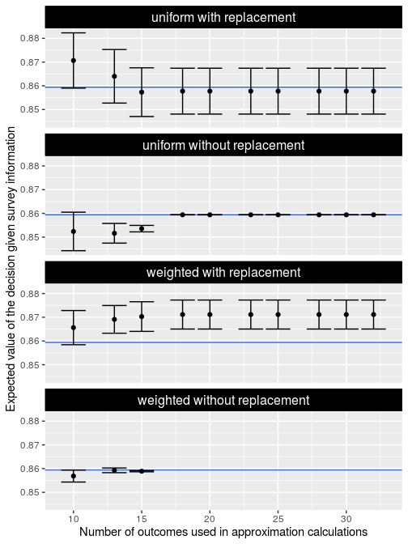

```r
# create plot
ggplot() +
geom_hline(yintercept = ev_survey, colour = "#3366FF") +
geom_point(aes(x = n, y = mean), ev_prime_survey) +
geom_errorbar(aes(x = n, ymin = lower, ymax = upper), ev_prime_survey) +
facet_wrap(~ method, ncol = 1) +
xlab("Number of outcomes used in approximation calculations") +
ylab("Expected value of the decision given survey information") +
theme(strip.background = element_rect(color = "black", fill = "black"),
      strip.text = element_text(color = "white", size = 12))
```

Broadly speaking, we can see that the estimates (points) get closer to the correct value (blue line) when more outcomes are used in the approximation calculations (greater values on the x-axis). Furthermore, we can see that the estimates become more precise (smaller error bars) when more outcomes are used in the approximation calculations (greater values on the x-axis). This pattern is true for most of the sampling methods – except for the *weighted with replacement* method which performs really poorly – and shows that most the approximation method is more accurate when we use a greater number of outcomes for the calculations. In particular, we can see that the *weighted without replacement* method is the most useful because it converges to the correct value (blue line) with the fewest approximation outcomes.